# Overview of `strikes`

**Overview**

Table Overview

| Columns | 21 |
| --- | --- |
| Rows | 56,978 |
| `NA`s | 205,063 (17.14%) |
| Duplicate Rows | 529 (0.93%) |

Column Types

| character | 13 |
| --- | --- |
| numeric | 7 |
| POSIXct | 1 |

**Reproducibility**

Reproducibility Information

| Scan Build Time | `2021-07-20 15:24:25` |
| --- | --- |
| **pointblank** Version | `0.7.0.9000` |
| **R** Version | R version 4.0.3 (2020–10–10) *Bunny–Wunnies Freak Out* |
| Operating System | `x86_64-pc-linux-gnu` |

# Variables

incident_date  
`datetime`

| Distinct | 9,880 (17.34%) |
| --- | --- |
| `NA`s | 0 |
| `Inf`/`-Inf` | 0 |

state  
`character`

| Distinct | 59 (0.10%) |
| --- | --- |
| `NA`s | 0 |
| `Inf`/`-Inf` | 0 |

**Common Values**

| Value | Count | Frequency |
| --- | --- | --- |
| N/A | 12671 | 22.2% |
| TX | 7146 | 12.5% |
| CA | 5780 | 10.1% |
| FL | 3686 | 6.5% |
| IL | 2744 | 4.8% |
| CO | 2441 | 4.3% |
| NY | 2242 | 3.9% |
| MO | 1674 | 2.9% |
| TN | 1251 | 2.2% |
| **Other Values** (16115) | 16115 | 28.3% |

**String Lengths**

String Lengths

| Mean | 2.2 |
| --- | --- |
| Minimum | 2.0 |
| Maximum | 3.0 |

Histogram

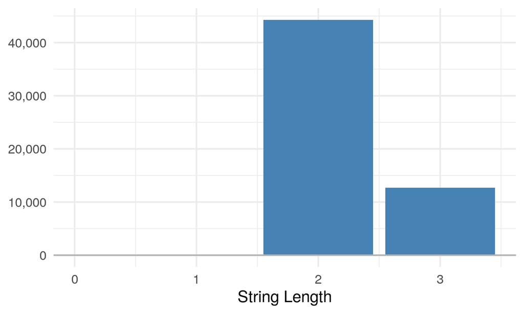

airport_id  
`character`

| Distinct | 423 (0.74%) |
| --- | --- |
| `NA`s | 0 |
| `Inf`/`-Inf` | 0 |

**Common Values**

| Value | Count | Frequency |
| --- | --- | --- |
| ZZZZ | 11046 | 19.4% |
| KDFW | 2455 | 4.3% |
| KDEN | 2249 | 3.9% |
| KORD | 1968 | 3.5% |
| KSMF | 1651 | 2.9% |
| KMCO | 1067 | 1.9% |
| KSLC | 1052 | 1.8% |
| KBWI | 1051 | 1.8% |
| KBNA | 1024 | 1.8% |
| **Other Values** (32397) | 32397 | 56.9% |

**String Lengths**

String Lengths

| Mean | 4.0 |
| --- | --- |
| Minimum | 3.0 |
| Maximum | 5.0 |

Histogram

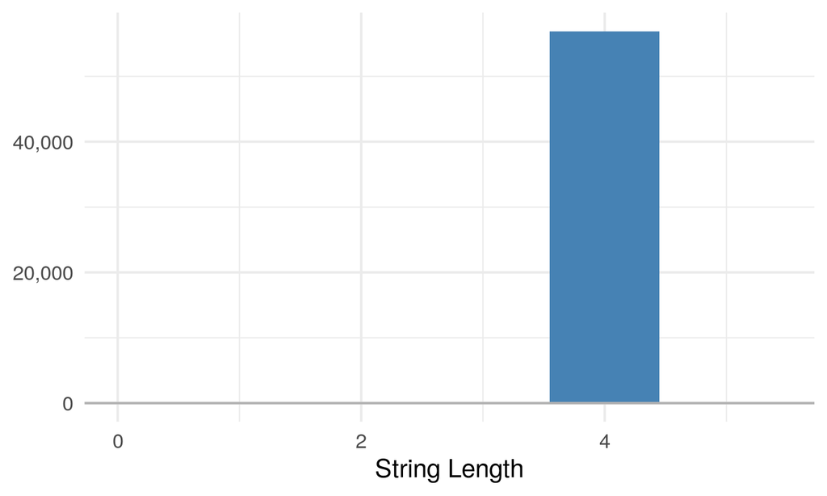

airport  
`character`

| Distinct | 423 (0.74%) |
| --- | --- |
| `NA`s | 0 |
| `Inf`/`-Inf` | 0 |

**Common Values**

| Value | Count | Frequency |
| --- | --- | --- |
| UNKNOWN | 11046 | 19.4% |
| DALLAS/FORT WORTH INTL ARPT | 2455 | 4.3% |
| DENVER INTL AIRPORT | 2249 | 3.9% |
| CHICAGO O'HARE INTL ARPT | 1968 | 3.5% |
| SACRAMENTO INTL | 1651 | 2.9% |
| ORLANDO INTL | 1067 | 1.9% |
| SALT LAKE CITY INTL | 1052 | 1.8% |
| BALTIMORE/WASH INTL THURGOOD MARSHAL ARPT | 1051 | 1.8% |
| NASHVILLE INTL | 1024 | 1.8% |
| **Other Values** (32397) | 32397 | 56.9% |

**String Lengths**

String Lengths

| Mean | 19.4 |
| --- | --- |
| Minimum | 4.0 |
| Maximum | 53.0 |

Histogram

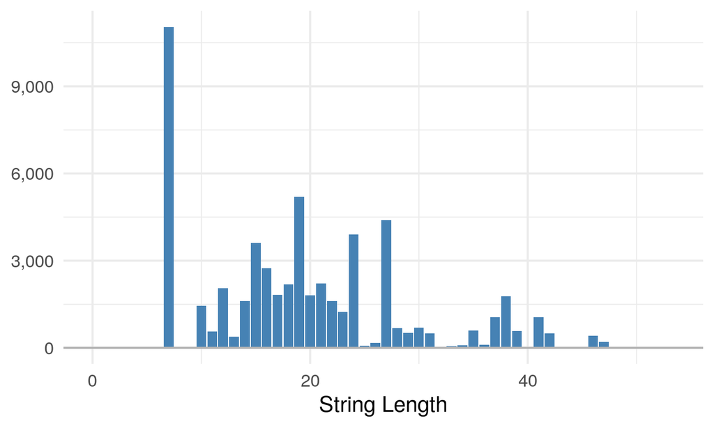

operator  
`character`

| Distinct | 4 (0.01%) |
| --- | --- |
| `NA`s | 0 |
| `Inf`/`-Inf` | 0 |

**Common Values**

| Value | Count | Frequency |
| --- | --- | --- |
| SOUTHWEST AIRLINES | 17970 | 31.5% |
| UNITED AIRLINES | 15116 | 26.5% |
| AMERICAN AIRLINES | 14887 | 26.1% |
| DELTA AIR LINES | 9005 | 15.8% |
| **Other Values** (0) | 0 | 0.0% |

**String Lengths**

String Lengths

| Mean | 16.5 |
| --- | --- |
| Minimum | 15.0 |
| Maximum | 18.0 |

Histogram

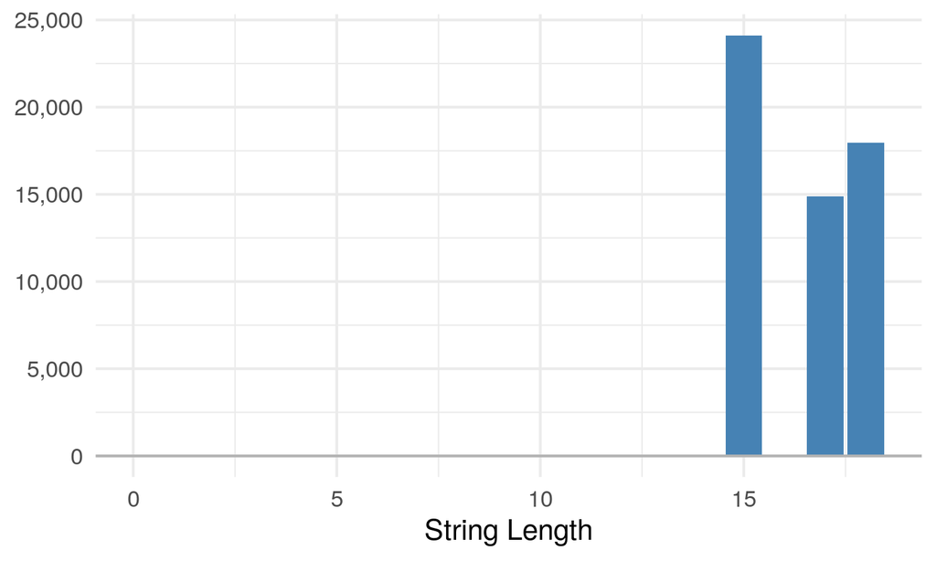

atype  
`character`

| Distinct | 91 (0.16%) |
| --- | --- |
| `NA`s | 0 |
| `Inf`/`-Inf` | 0 |

**Common Values**

| Value | Count | Frequency |
| --- | --- | --- |
| B-737-700 | 9964 | 17.5% |
| B-737-300 | 7641 | 13.4% |
| B-737-800 | 5230 | 9.2% |
| B-757-200 | 4235 | 7.4% |
| A-320 | 3776 | 6.6% |
| A-319 | 3057 | 5.4% |
| MD-82 | 2137 | 3.8% |
| MD-80 | 1960 | 3.4% |
| B-737-500 | 1933 | 3.4% |
| **Other Values** (15189) | 15189 | 26.7% |

**String Lengths**

String Lengths

| Mean | 7.7 |
| --- | --- |
| Minimum | 4.0 |
| Maximum | 18.0 |

Histogram

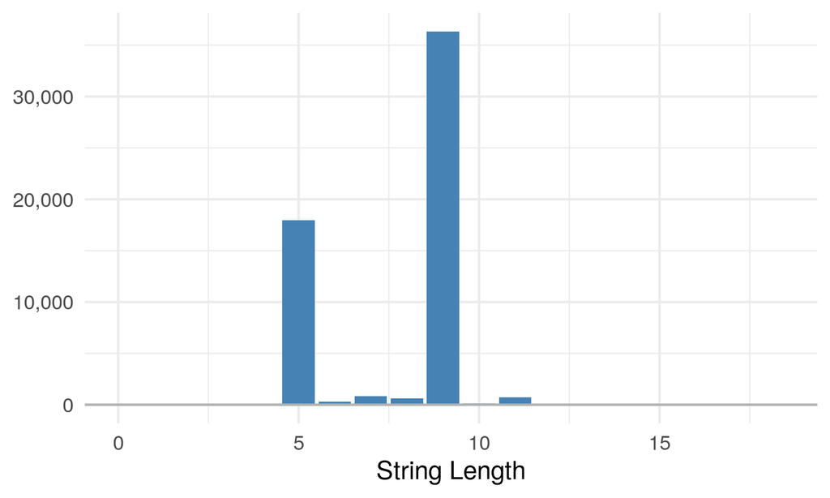

type_eng  
`character`

| Distinct | 5 (0.01%) |
| --- | --- |
| `NA`s | 234 (0.41%) |
| `Inf`/`-Inf` | 0 |

**Common Values**

| Value | Count | Frequency |
| --- | --- | --- |
| D | 56705 | 99.5% |
| `NA` | 234 | 0.4% |
| C | 34 | 0.1% |
| F | 3 | 0.0% |
| A | 2 | 0.0% |
| **Other Values** (0) | 0 | 0.0% |

**String Lengths**

String Lengths

| Mean | 1.0 |
| --- | --- |
| Minimum | 1.0 |
| Maximum | 1.0 |

Histogram

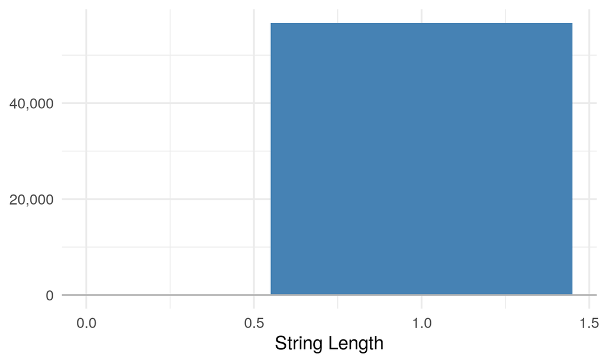

species_id  
`character`

| Distinct | 528 (0.93%) |
| --- | --- |
| `NA`s | 0 |
| `Inf`/`-Inf` | 0 |

**Common Values**

| Value | Count | Frequency |
| --- | --- | --- |
| UNKBM | 15394 | 27.0% |
| UNKBS | 14765 | 25.9% |
| UNKB | 3956 | 6.9% |
| NE1 | 1504 | 2.6% |
| O2205 | 1341 | 2.4% |
| YI005 | 1171 | 2.1% |
| UNKBL | 933 | 1.6% |
| YL001 | 848 | 1.5% |
| YH004 | 836 | 1.5% |
| **Other Values** (15435) | 15435 | 27.1% |

**String Lengths**

String Lengths

| Mean | 4.7 |
| --- | --- |
| Minimum | 1.0 |
| Maximum | 6.0 |

Histogram

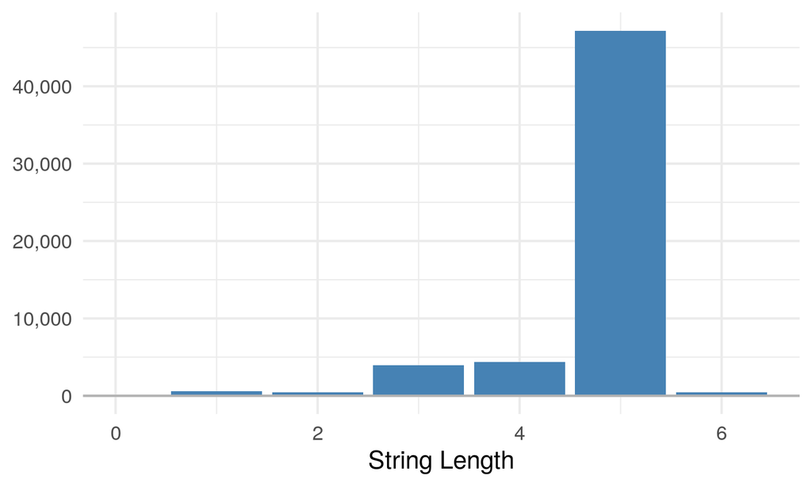

species  
`character`

| Distinct | 527 (0.92%) |
| --- | --- |
| `NA`s | 0 |
| `Inf`/`-Inf` | 0 |

**Common Values**

| Value | Count | Frequency |
| --- | --- | --- |
| Unknown bird - medium | 15394 | 27.0% |
| Unknown bird - small | 14765 | 25.9% |
| Unknown bird | 3956 | 6.9% |
| Gulls | 1504 | 2.6% |
| Mourning dove | 1341 | 2.4% |
| Barn swallow | 1171 | 2.1% |
| Unknown bird - large | 933 | 1.6% |
| European starling | 848 | 1.5% |
| Horned lark | 836 | 1.5% |
| **Other Values** (15435) | 15435 | 27.1% |

**String Lengths**

String Lengths

| Mean | 17.0 |
| --- | --- |
| Minimum | 4.0 |
| Maximum | 50.0 |

Histogram

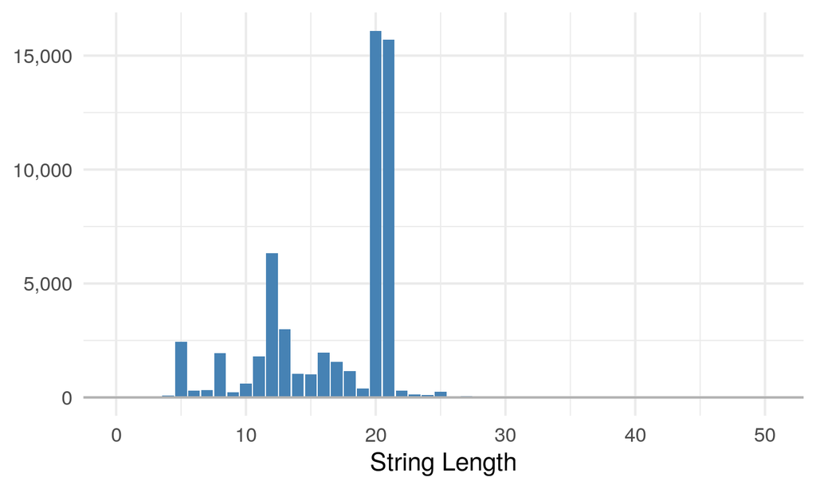

damage  
`character`

| Distinct | 5 (0.01%) |
| --- | --- |
| `NA`s | 4,324 (7.59%) |
| `Inf`/`-Inf` | 0 |

**Common Values**

| Value | Count | Frequency |
| --- | --- | --- |
| N | 48650 | 85.4% |
| `NA` | 4324 | 7.6% |
| M | 1892 | 3.3% |
| M? | 1085 | 1.9% |
| S | 1027 | 1.8% |
| **Other Values** (0) | 0 | 0.0% |

**String Lengths**

String Lengths

| Mean | 1.0 |
| --- | --- |
| Minimum | 1.0 |
| Maximum | 2.0 |

Histogram

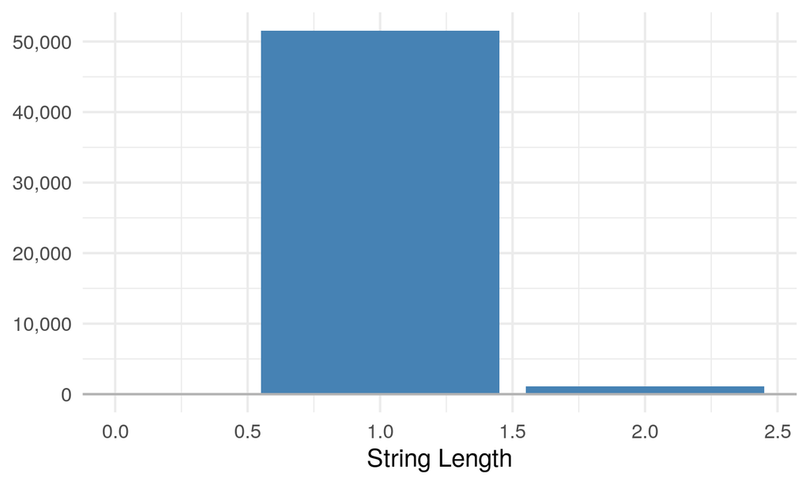

num_engs  
`numeric`

| Distinct | 5 (0.01%) |
| --- | --- |
| `NA`s | 233 (0.41%) |
| `Inf`/`-Inf` | 0 |

| Mean | 2.06 |
| --- | --- |
| Minimum | 1 |
| Maximum | 4 |

**Statistics**

Quantile Statistics

| Minimum | 1.00 |
| --- | --- |
| 5th Percentile | 2.00 |
| Q1 | 2.00 |
| Median | 2.00 |
| Q3 | 2.00 |
| 95th Percentile | 3.00 |
| Maximum | 4.00 |
| Range | 3.00 |
| IQR | 0.00 |

Descriptive Statistics

| Mean | 2.06 |
| --- | --- |
| Variance | 0.07 |
| Standard Deviation | 0.26 |
| Coefficient of Variation | 0.12 |

**Common Values**

| Value | Count | Frequency |
| --- | --- | --- |
| 2 | 53692 | 94.2% |
| 3 | 2753 | 4.8% |
| 4 | 299 | 0.5% |
| `NA` | 233 | 0.4% |
| 1 | 1 | 0.0% |
| **Other Values** (0) | 0 | 0.0% |

**Max/Min Slices**

Maximum Values

| Value | Count | Frequency |
| --- | --- | --- |
| 2 | 53692 | 94.23% |
| 3 | 2753 | 4.83% |
| 4 | 299 | 0.52% |
| `NA` | 233 | 0.41% |
| 1 | 1 | 0.00% |

Minimum Values

| Value | Count | Frequency |
| --- | --- | --- |
| 1 | 1 | 0.00% |
| `NA` | 233 | 0.41% |
| 4 | 299 | 0.52% |
| 3 | 2753 | 4.83% |
| 2 | 53692 | 94.23% |

incident_month  
`numeric`

| Distinct | 12 (0.02%) |
| --- | --- |
| `NA`s | 0 |
| `Inf`/`-Inf` | 0 |

| Mean | 7.24 |
| --- | --- |
| Minimum | 1 |
| Maximum | 12 |

**Statistics**

Quantile Statistics

| Minimum | 1.00 |
| --- | --- |
| 5th Percentile | 2.00 |
| Q1 | 5.00 |
| Median | 8.00 |
| Q3 | 10.00 |
| 95th Percentile | 11.00 |
| Maximum | 12.00 |
| Range | 11.00 |
| IQR | 5.00 |

Descriptive Statistics

| Mean | 7.24 |
| --- | --- |
| Variance | 7.99 |
| Standard Deviation | 2.83 |
| Coefficient of Variation | 0.39 |

**Common Values**

| Value | Count | Frequency |
| --- | --- | --- |
| 9 | 7980 | 14.0% |
| 10 | 7754 | 13.6% |
| 8 | 7104 | 12.5% |
| 5 | 6161 | 10.8% |
| 7 | 6133 | 10.8% |
| 6 | 4541 | 8.0% |
| 4 | 4490 | 7.9% |
| 11 | 4191 | 7.4% |
| 3 | 2678 | 4.7% |
| **Other Values** (3643) | 3643 | 6.4% |

**Max/Min Slices**

Maximum Values

| Value | Count | Frequency |
| --- | --- | --- |
| 9 | 7980 | 14.01% |
| 10 | 7754 | 13.61% |
| 8 | 7104 | 12.47% |
| 5 | 6161 | 10.81% |
| 7 | 6133 | 10.76% |
| 6 | 4541 | 7.97% |
| 4 | 4490 | 7.88% |
| 11 | 4191 | 7.36% |
| 3 | 2678 | 4.70% |
| 12 | 2303 | 4.04% |

Minimum Values

| Value | Count | Frequency |
| --- | --- | --- |
| 2 | 1692 | 2.97% |
| 1 | 1951 | 3.42% |
| 12 | 2303 | 4.04% |
| 3 | 2678 | 4.70% |
| 11 | 4191 | 7.36% |
| 4 | 4490 | 7.88% |
| 6 | 4541 | 7.97% |
| 7 | 6133 | 10.76% |
| 5 | 6161 | 10.81% |
| 8 | 7104 | 12.47% |

incident_year  
`numeric`

| Distinct | 29 (0.05%) |
| --- | --- |
| `NA`s | 0 |
| `Inf`/`-Inf` | 0 |

| Mean | 2,007.83 |
| --- | --- |
| Minimum | 1,990 |
| Maximum | 2,018 |

**Statistics**

Quantile Statistics

| Minimum | 1,990.00 |
| --- | --- |
| 5th Percentile | 1,993.00 |
| Q1 | 2,001.00 |
| Median | 2,009.00 |
| Q3 | 2,015.00 |
| 95th Percentile | 2,018.00 |
| Maximum | 2,018.00 |
| Range | 28.00 |
| IQR | 14.00 |

Descriptive Statistics

| Mean | 2,007.83 |
| --- | --- |
| Variance | 63.20 |
| Standard Deviation | 7.95 |
| Coefficient of Variation | 0.00 |

**Common Values**

| Value | Count | Frequency |
| --- | --- | --- |
| 2018 | 4452 | 7.8% |
| 2017 | 4081 | 7.2% |
| 2016 | 3764 | 6.6% |
| 2015 | 3602 | 6.3% |
| 2014 | 3102 | 5.4% |
| 2013 | 2681 | 4.7% |
| 2012 | 2517 | 4.4% |
| 2000 | 2303 | 4.0% |
| 2010 | 2104 | 3.7% |
| **Other Values** (26270) | 26270 | 46.1% |

**Max/Min Slices**

Maximum Values

| Value | Count | Frequency |
| --- | --- | --- |
| 2018 | 4452 | 7.81% |
| 2017 | 4081 | 7.16% |
| 2016 | 3764 | 6.61% |
| 2015 | 3602 | 6.32% |
| 2014 | 3102 | 5.44% |
| 2013 | 2681 | 4.71% |
| 2012 | 2517 | 4.42% |
| 2000 | 2303 | 4.04% |
| 2010 | 2104 | 3.69% |
| 2009 | 2102 | 3.69% |

Minimum Values

| Value | Count | Frequency |
| --- | --- | --- |
| 1990 | 651 | 1.14% |
| 1994 | 849 | 1.49% |
| 1993 | 873 | 1.53% |
| 1998 | 886 | 1.55% |
| 1995 | 898 | 1.58% |
| 1991 | 906 | 1.59% |
| 1992 | 915 | 1.61% |
| 1996 | 945 | 1.66% |
| 1997 | 1012 | 1.78% |
| 2006 | 1359 | 2.39% |

time_of_day  
`character`

| Distinct | 5 (0.01%) |
| --- | --- |
| `NA`s | 16,133 (28.31%) |
| `Inf`/`-Inf` | 0 |

**Common Values**

| Value | Count | Frequency |
| --- | --- | --- |
| Day | 25123 | 44.1% |
| `NA` | 16133 | 28.3% |
| Night | 12735 | 22.4% |
| Dusk | 1717 | 3.0% |
| Dawn | 1270 | 2.2% |
| **Other Values** (0) | 0 | 0.0% |

**String Lengths**

String Lengths

| Mean | 3.7 |
| --- | --- |
| Minimum | 3.0 |
| Maximum | 5.0 |

Histogram

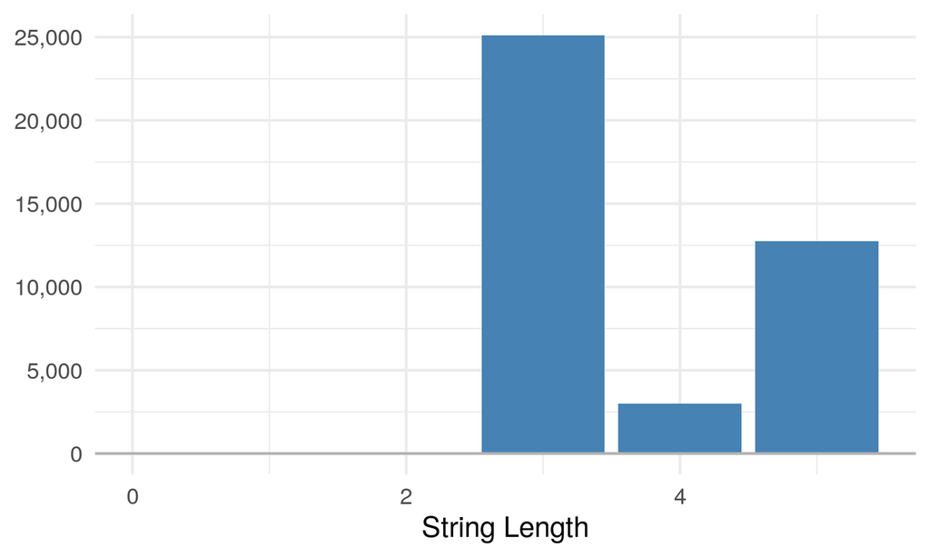

time  
`numeric`

| Distinct | 1,331 (2.34%) |
| --- | --- |
| `NA`s | 26,124 (45.85%) |
| `Inf`/`-Inf` | 0 |

| Mean | 1,427.55 |
| --- | --- |
| Minimum | −84 |
| Maximum | 2,359 |

**Statistics**

Quantile Statistics

| Minimum | −84.00 |
| --- | --- |
| 5th Percentile | 618.00 |
| Q1 | 930.00 |
| Median | 1,426.00 |
| Q3 | 1,950.00 |
| 95th Percentile | 2,258.00 |
| Maximum | 2,359.00 |
| Range | 2,443.00 |
| IQR | 1,020.00 |

Descriptive Statistics

| Mean | 1,427.55 |
| --- | --- |
| Variance | 338,406.27 |
| Standard Deviation | 581.73 |
| Coefficient of Variation | 0.41 |

**Common Values**

| Value | Count | Frequency |
| --- | --- | --- |
| `NA` | 26124 | 45.8% |
| 2100 | 337 | 0.6% |
| 2200 | 298 | 0.5% |
| 2300 | 266 | 0.5% |
| 900 | 264 | 0.5% |
| 800 | 263 | 0.5% |
| 1000 | 249 | 0.4% |
| 2000 | 249 | 0.4% |
| 2130 | 242 | 0.4% |
| **Other Values** (28446) | 28446 | 49.9% |

**Max/Min Slices**

Maximum Values

| Value | Count | Frequency |
| --- | --- | --- |
| `NA` | 26124 | 45.85% |
| 2100 | 337 | 0.59% |
| 2200 | 298 | 0.52% |
| 2300 | 266 | 0.47% |
| 900 | 264 | 0.46% |
| 800 | 263 | 0.46% |
| 1000 | 249 | 0.44% |
| 2000 | 249 | 0.44% |
| 2130 | 242 | 0.42% |
| 1100 | 240 | 0.42% |

Minimum Values

| Value | Count | Frequency |
| --- | --- | --- |
| -84 | 1 | 0.00% |
| 29 | 1 | 0.00% |
| 34 | 1 | 0.00% |
| 47 | 1 | 0.00% |
| 53 | 1 | 0.00% |
| 57 | 1 | 0.00% |
| 58 | 1 | 0.00% |
| 102 | 1 | 0.00% |
| 103 | 1 | 0.00% |
| 107 | 1 | 0.00% |

height  
`numeric`

| Distinct | 340 (0.60%) |
| --- | --- |
| `NA`s | 18,038 (31.66%) |
| `Inf`/`-Inf` | 0 |

| Mean | 983.83 |
| --- | --- |
| Minimum | 0 |
| Maximum | 25,000 |

**Statistics**

Quantile Statistics

| Minimum | 0.00 |
| --- | --- |
| 5th Percentile | 0.00 |
| Q1 | 0.00 |
| Median | 50.00 |
| Q3 | 1,000.00 |
| 95th Percentile | 5,000.00 |
| Maximum | 25,000.00 |
| Range | 25,000.00 |
| IQR | 1,000.00 |

Descriptive Statistics

| Mean | 983.83 |
| --- | --- |
| Variance | 4,107,745.54 |
| Standard Deviation | 2,026.76 |
| Coefficient of Variation | 2.06 |

**Common Values**

| Value | Count | Frequency |
| --- | --- | --- |
| `NA` | 18038 | 31.7% |
| 0 | 15684 | 27.5% |
| 100 | 1793 | 3.1% |
| 50 | 1572 | 2.8% |
| 500 | 1460 | 2.6% |
| 200 | 1433 | 2.5% |
| 1000 | 1354 | 2.4% |
| 300 | 1143 | 2.0% |
| 10 | 1078 | 1.9% |
| **Other Values** (12347) | 12347 | 21.7% |

**Max/Min Slices**

Maximum Values

| Value | Count | Frequency |
| --- | --- | --- |
| `NA` | 18038 | 31.66% |
| 0 | 15684 | 27.53% |
| 100 | 1793 | 3.15% |
| 50 | 1572 | 2.76% |
| 500 | 1460 | 2.56% |
| 200 | 1433 | 2.52% |
| 1000 | 1354 | 2.38% |
| 300 | 1143 | 2.01% |
| 10 | 1078 | 1.89% |
| 3000 | 1076 | 1.89% |

Minimum Values

| Value | Count | Frequency |
| --- | --- | --- |
| 18 | 1 | 0.00% |
| 22 | 1 | 0.00% |
| 23 | 1 | 0.00% |
| 26 | 1 | 0.00% |
| 27 | 1 | 0.00% |
| 36 | 1 | 0.00% |
| 37 | 1 | 0.00% |
| 42 | 1 | 0.00% |
| 46 | 1 | 0.00% |
| 47 | 1 | 0.00% |

speed  
`numeric`

| Distinct | 166 (0.29%) |
| --- | --- |
| `NA`s | 30,046 (52.73%) |
| `Inf`/`-Inf` | 0 |

| Mean | 154.55 |
| --- | --- |
| Minimum | 0 |
| Maximum | 354 |

**Statistics**

Quantile Statistics

| Minimum | 0.00 |
| --- | --- |
| 5th Percentile | 100.00 |
| Q1 | 130.00 |
| Median | 140.00 |
| Q3 | 170.00 |
| 95th Percentile | 250.00 |
| Maximum | 354.00 |
| Range | 354.00 |
| IQR | 40.00 |

Descriptive Statistics

| Mean | 154.55 |
| --- | --- |
| Variance | 1,787.71 |
| Standard Deviation | 42.28 |
| Coefficient of Variation | 0.27 |

**Common Values**

| Value | Count | Frequency |
| --- | --- | --- |
| `NA` | 30046 | 52.7% |
| 140 | 3767 | 6.6% |
| 130 | 2427 | 4.3% |
| 150 | 2284 | 4.0% |
| 135 | 2094 | 3.7% |
| 250 | 1587 | 2.8% |
| 120 | 1507 | 2.6% |
| 210 | 1289 | 2.3% |
| 160 | 1221 | 2.1% |
| **Other Values** (9541) | 9541 | 16.7% |

**Max/Min Slices**

Maximum Values

| Value | Count | Frequency |
| --- | --- | --- |
| `NA` | 30046 | 52.73% |
| 140 | 3767 | 6.61% |
| 130 | 2427 | 4.26% |
| 150 | 2284 | 4.01% |
| 135 | 2094 | 3.68% |
| 250 | 1587 | 2.79% |
| 120 | 1507 | 2.64% |
| 210 | 1289 | 2.26% |
| 160 | 1221 | 2.14% |
| 100 | 1215 | 2.13% |

Minimum Values

| Value | Count | Frequency |
| --- | --- | --- |
| 9 | 1 | 0.00% |
| 12 | 1 | 0.00% |
| 56 | 1 | 0.00% |
| 82 | 1 | 0.00% |
| 87 | 1 | 0.00% |
| 88 | 1 | 0.00% |
| 91 | 1 | 0.00% |
| 92 | 1 | 0.00% |
| 99 | 1 | 0.00% |
| 104 | 1 | 0.00% |

phase_of_flt  
`character`

| Distinct | 25 (0.04%) |
| --- | --- |
| `NA`s | 11,469 (20.13%) |
| `Inf`/`-Inf` | 0 |

**Common Values**

| Value | Count | Frequency |
| --- | --- | --- |
| Approach | 20604 | 36.2% |
| `NA` | 11469 | 20.1% |
| Take-off run | 8233 | 14.4% |
| Climb | 7657 | 13.4% |
| Landing Roll | 7244 | 12.7% |
| Descent | 661 | 1.2% |
| Departure | 447 | 0.8% |
| Arrival | 179 | 0.3% |
| Local | 116 | 0.2% |
| **Other Values** (287) | 287 | 0.5% |

**String Lengths**

String Lengths

| Mean | 8.8 |
| --- | --- |
| Minimum | 4.0 |
| Maximum | 12.0 |

Histogram

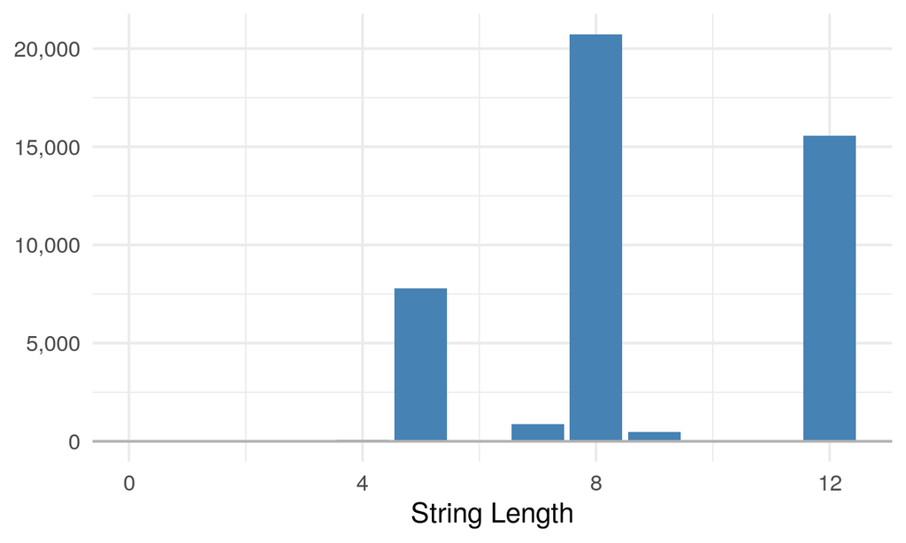

sky  
`character`

| Distinct | 4 (0.01%) |
| --- | --- |
| `NA`s | 20,485 (35.95%) |
| `Inf`/`-Inf` | 0 |

**Common Values**

| Value | Count | Frequency |
| --- | --- | --- |
| `NA` | 20485 | 36.0% |
| No Cloud | 18937 | 33.2% |
| Some Cloud | 12107 | 21.2% |
| Overcast | 5449 | 9.6% |
| **Other Values** (0) | 0 | 0.0% |

**String Lengths**

String Lengths

| Mean | 8.7 |
| --- | --- |
| Minimum | 8.0 |
| Maximum | 10.0 |

Histogram

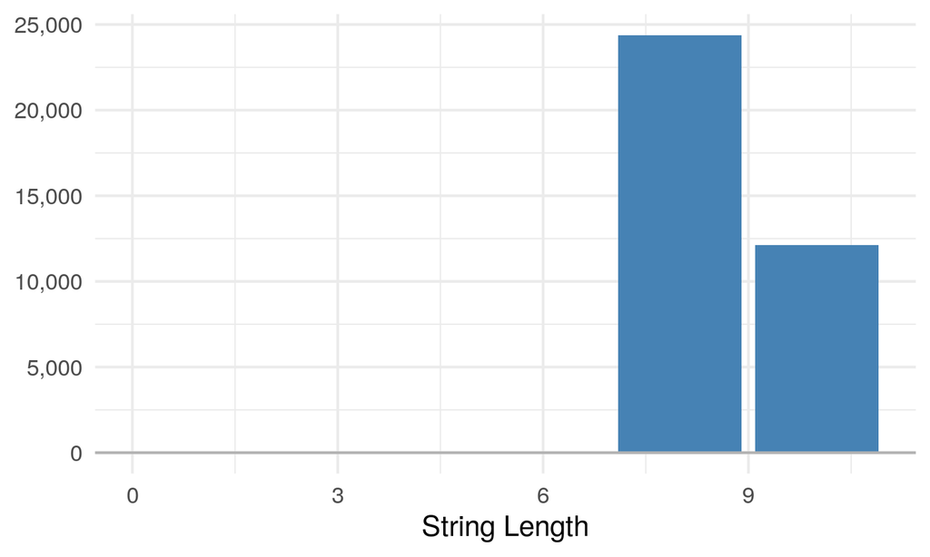

precip  
`character`

| Distinct | 8 (0.01%) |
| --- | --- |
| `NA`s | 21,614 (37.93%) |
| `Inf`/`-Inf` | 0 |

**Common Values**

| Value | Count | Frequency |
| --- | --- | --- |
| None | 32937 | 57.8% |
| `NA` | 21614 | 37.9% |
| Rain | 1689 | 3.0% |
| Fog | 587 | 1.0% |
| Snow | 85 | 0.1% |
| Fog, Rain | 58 | 0.1% |
| Fog, Snow | 5 | 0.0% |
| Rain, Snow | 3 | 0.0% |
| **Other Values** (0) | 0 | 0.0% |

**String Lengths**

String Lengths

| Mean | 4.0 |
| --- | --- |
| Minimum | 3.0 |
| Maximum | 10.0 |

Histogram

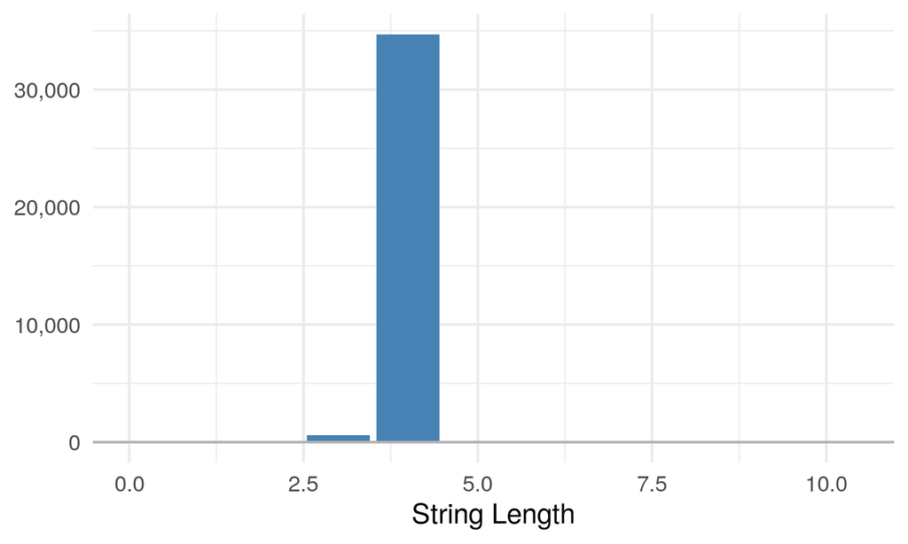

cost_repairs_infl_adj  
`numeric`

| Distinct | 529 (0.93%) |
| --- | --- |
| `NA`s | 56,363 (98.92%) |
| `Inf`/`-Inf` | 0 |

| Mean | 242,387.9 |
| --- | --- |
| Minimum | 11 |
| Maximum | 16,380,000 |

**Statistics**

Quantile Statistics

| Minimum | 11.00 |
| --- | --- |
| 5th Percentile | 161.10 |
| Q1 | 5,128.00 |
| Median | 26,783.00 |
| Q3 | 93,123.50 |
| 95th Percentile | 1,370,044.00 |
| Maximum | 16,380,000.00 |
| Range | 16,379,989.00 |
| IQR | 87,995.50 |

Descriptive Statistics

| Mean | 242,387.90 |
| --- | --- |
| Variance | 888,497,541,965.93 |
| Standard Deviation | 942,601.48 |
| Coefficient of Variation | 3.89 |

**Common Values**

| Value | Count | Frequency |
| --- | --- | --- |
| `NA` | 56363 | 98.9% |
| 102 | 6 | 0.0% |
| 32100 | 5 | 0.0% |
| 100 | 4 | 0.0% |
| 500 | 4 | 0.0% |
| 10590 | 4 | 0.0% |
| 265000 | 4 | 0.0% |
| 108 | 3 | 0.0% |
| 1059 | 3 | 0.0% |
| **Other Values** (579) | 579 | 1.0% |

**Max/Min Slices**

Maximum Values

| Value | Count | Frequency |
| --- | --- | --- |
| `NA` | 56363 | 98.92% |
| 102 | 6 | 0.01% |
| 32100 | 5 | 0.01% |
| 100 | 4 | 0.01% |
| 500 | 4 | 0.01% |
| 10590 | 4 | 0.01% |
| 265000 | 4 | 0.01% |
| 108 | 3 | 0.01% |
| 1059 | 3 | 0.01% |
| 5308 | 3 | 0.01% |

Minimum Values

| Value | Count | Frequency |
| --- | --- | --- |
| 11 | 1 | 0.00% |
| 28 | 1 | 0.00% |
| 50 | 1 | 0.00% |
| 51 | 1 | 0.00% |
| 53 | 1 | 0.00% |
| 88 | 1 | 0.00% |
| 91 | 1 | 0.00% |
| 93 | 1 | 0.00% |
| 94 | 1 | 0.00% |
| 105 | 1 | 0.00% |

# Interactions

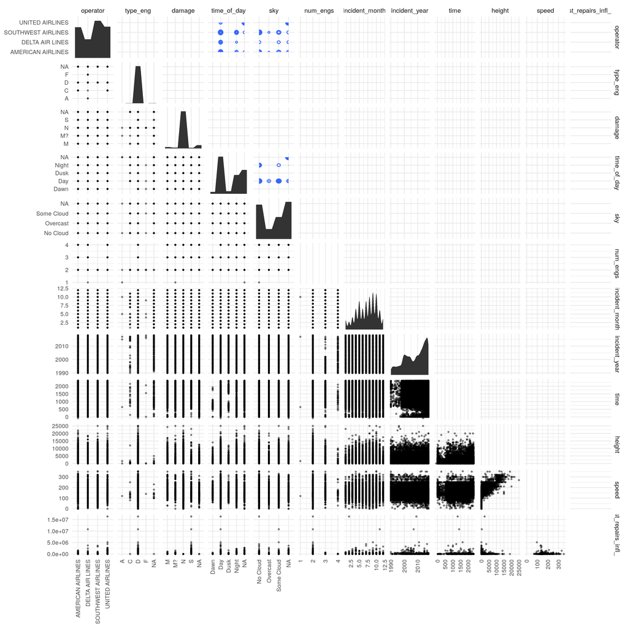

# Correlations

**Pearson**

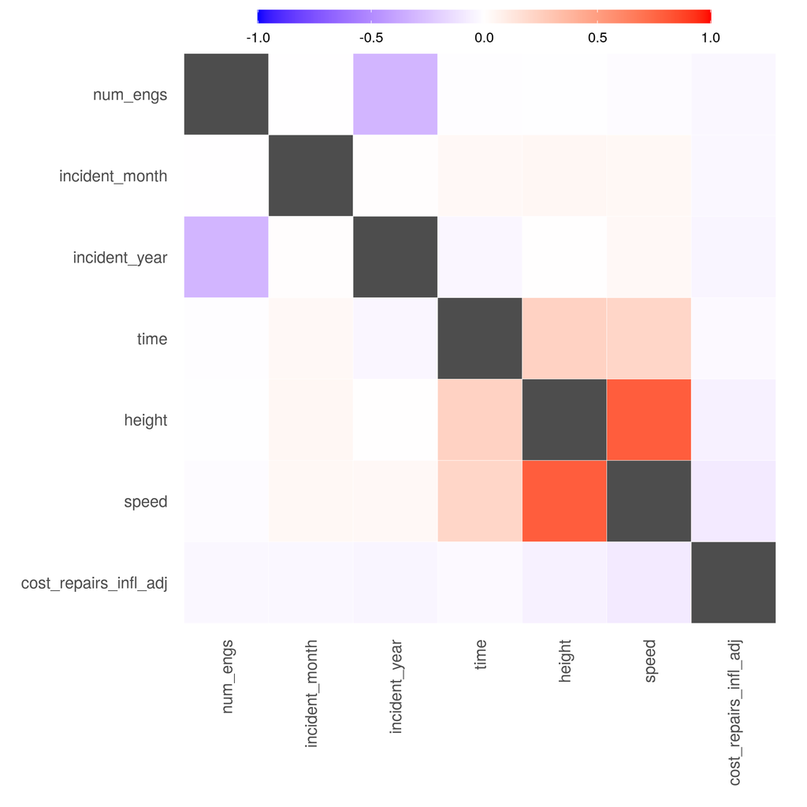

**Kendall**

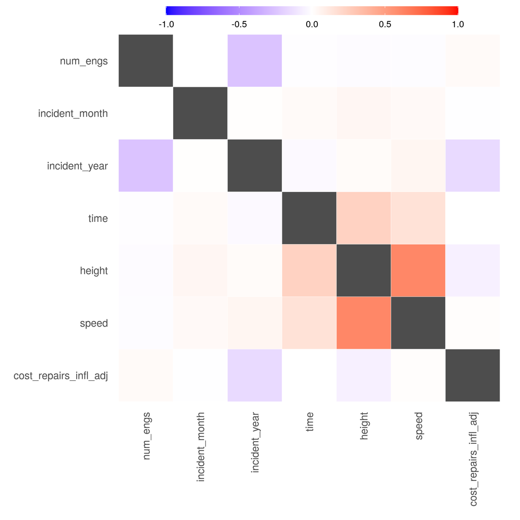

**Spearman**

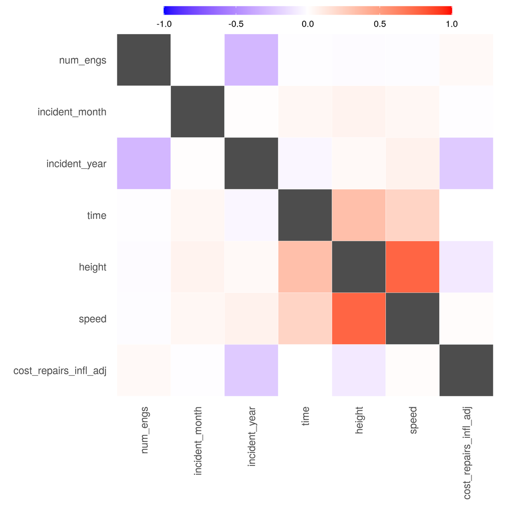

# Missing Values

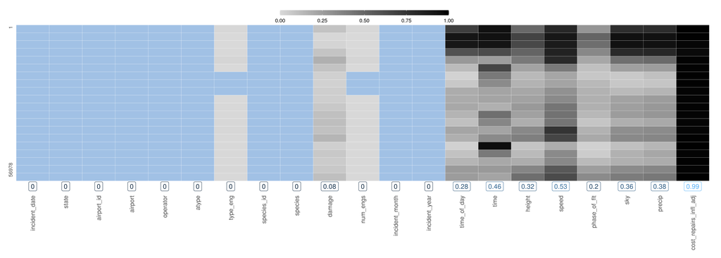

# Sample

|  | incident_date | state | airport_id | airport | operator | atype | type_eng | species_id | species | damage | num_engs | incident_month | incident_year | time_of_day | time | height | speed | phase_of_flt | sky | precip | cost_repairs_infl_adj |
| --- | --- | --- | --- | --- | --- | --- | --- | --- | --- | --- | --- | --- | --- | --- | --- | --- | --- | --- | --- | --- | --- |
| 1 | 2018-12-31 | FL | KMIA | MIAMI INTL | AMERICAN AIRLINES | B-737-800 | D | UNKBL | Unknown bird - large | M? | 2 | 12 | 2018 | Day | 1207 | 700 | 200 | Climb | Some Cloud | None | `NA` |
| 2 | 2018-12-29 | IN | KIND | INDIANAPOLIS INTL ARPT | AMERICAN AIRLINES | B-737-800 | D | R | Owls | N | 2 | 12 | 2018 | Night | 2355 | 0 | `NA` | Landing Roll | `NA` | `NA` | `NA` |
| 3 | 2018-12-29 | N/A | ZZZZ | UNKNOWN | AMERICAN AIRLINES | UNKNOWN | `NA` | R2004 | Short-eared owl | `NA` | `NA` | 12 | 2018 | `NA` | `NA` | `NA` | `NA` | `NA` | `NA` | `NA` | `NA` |
| 4 | 2018-12-27 | N/A | ZZZZ | UNKNOWN | AMERICAN AIRLINES | B-737-900 | D | N5205 | Southern lapwing | M? | 2 | 12 | 2018 | `NA` | `NA` | `NA` | `NA` | `NA` | `NA` | `NA` | `NA` |
| 5 | 2018-12-27 | N/A | ZZZZ | UNKNOWN | AMERICAN AIRLINES | B-737-800 | D | J2139 | Lesser scaup | M? | 2 | 12 | 2018 | `NA` | `NA` | `NA` | `NA` | `NA` | `NA` | `NA` | `NA` |
| 6..56973 |  |  |  |  |  |  |  |  |  |  |  |  |  |  |  |  |  |  |  |  |  |
| 56974 | 1990-04-23 | NY | KJFK | JOHN F KENNEDY INTL | UNITED AIRLINES | B-767-200 | D | NE1 | Gulls | N | 2 | 4 | 1990 | Dusk | `NA` | 1200 | `NA` | Approach | No Cloud | None | `NA` |
| 56975 | 1990-03-25 | CA | KSAN | SAN DIEGO INTL | UNITED AIRLINES | DC-8-70 | D | NE120 | Western gull | N | 4 | 3 | 1990 | `NA` | `NA` | 0 | `NA` | Landing Roll | `NA` | `NA` | `NA` |
| 56976 | 1990-03-09 | CA | KSFO | SAN FRANCISCO INTL ARPT | UNITED AIRLINES | B-737-300 | D | UNKBM | Unknown bird - medium | S | 2 | 3 | 1990 | `NA` | `NA` | 0 | `NA` | Landing Roll | `NA` | `NA` | `NA` |
| 56977 | 1990-02-24 | DC | KIAD | WASHINGTON DULLES INTL ARPT | UNITED AIRLINES | B-707 | D | J | Ducks, geese, swans | `NA` | 4 | 2 | 1990 | Night | `NA` | `NA` | `NA` | `NA` | No Cloud | None | `NA` |
| 56978 | 1990-02-14 | CA | KSMF | SACRAMENTO INTL | UNITED AIRLINES | B-737 | D | UNKBM | Unknown bird - medium | S | 2 | 2 | 1990 | `NA` | `NA` | 0 | `NA` | Take-off run | `NA` | `NA` | `NA` |